# Be Your Own Data Architect:

## Create Custom Datasets to Use for Machine Learning with TensorFlow

### David M. Clark

### February 15, 2018

## Outline

- Talk divided into two parts:
1. Background:
- Introduction to neural networks.
- Basic principals of recurrent neural networks (RNNs).
2. TensorFlow Model:
- Generate a custom dataset.
- Setup and run a TensorFlow model.

## What is a neural network?

- A type of machine learning based on how the brain works.
- Input is passed through neurons, which decide how important it is related to the output.
- Inputs are weighted and a bias term is applied.
- Decisions are made using an activation function.

[figure not shown]

[Neural Networks and Deep Learning](http://http://neuralnetworksanddeeplearning.com/)

## What is a neural network?

- Many inputs can pass through a single neuron.
- Hidden layer
- Layer of neurons between inputs and outputs.
- More complex decision-making ability.
- Inputs, layers of neurons, outputs ⇒ neural network.
- Deep learning
- Many hidden layers.
- Can make very complex decisions.

[figure not shown]

[Neural Networks and Deep Learning](http://http://neuralnetworksanddeeplearning.com/)

## Types of Deep Learning

### Convolution Neural Networks

[figure not shown]

- Neuron groups sample 2-dimensional plane.
- Many layered
- Feedforward neural network
- Image recognition

[Understanding Convolution Neural Networks for NLP](http://www.wildml.com/2015/11/understanding-convolutional-neural-networks-for-nlp/), WildML, November 7, 2015

## Types of Deep Learning

### Recurrent Neural Networks

[figure not shown]

- Usually single layered
- Information pulled through network like a ticker tape.
- State of RNN changes through time
- Network can learn a sequence.

[Understanding LSTM Networks](http://colah.github.io/posts/2015-08-Understanding-LSTMs/), colah's blog, August 27, 2015

## Types of Recurrent Neural Networks

[figure not shown]

**one to one**

- image classification

**one to many**

**many to one**

- sequence classification

**many to many**

- translation

**many to many**

- video classification

[The Unreasonable Effectiveness of Recurrent Neural Networks](http://karpathy.github.io/2015/05/21/rnn-effectiveness/), Andrej Karpathy blog, May 21, 2015

## RNN Concepts

- Backpropagation through time (BPTT).
- Vanishing/exploding gradients
- LSTMs

## Backpropagation

- Backpropagate errors through each layer in RNN.
- Number of layers = number of time steps in series.
- Backpropagation Through Time (BPTT).
- Challenges:
- Difficult to train long series.
- Shared weights.
- Slope of current gradient can directly affect slope of past gradients.
- Weight updates vs. accurate gradients.
- Solutions:
- Truncated backprogation
- LSTMs

## Backpropagation

**True backpropagation:**

[figure not shown]

**TensorFlow style backpropagation:**

- graph split into separate tensors

- each n backprop steps wide

[figure not shown]

[Styles of Truncated Backpropagation](http://r2rt.com/styles-of-truncated-backpropagation.html), R2RT, July 19, 2016

## Vanishing/Exploding Gradients

- Gradient can explode when backpropogation step is large.
- Clip gradients to prevent explosion.
- Vanishing gradients are more difficult to deal with.
- Good weight initialization important.
- What about variable gradients during training?
- LSTMs can solve this issue.

## Long Short-Term Memory

- Basic principle - write down information to remember.
- Main challenge - information overload.

## Long Short-Term Memory

- Overcoming LSTM challenges:
- Forget selectively.
- Read selectively.
- Write selectively.
- LSTM cell
- Forget gate.
- Input gate.
- Output gate.

## Forget Gate

- Decide what information to remove from cell state.
- Sigmoid layer.

[figure not shown]

[Understanding LSTM Networks](http://colah.github.io/posts/2015-08-Understanding-LSTMs/), colah's blog, August 27, 2015

## Input Gate

- Decide what information to store in cell state.
1. Decide what to update.
- sigmoid layer.
2. Create candidate values for cell state.
- tanh layer.

[figure not shown]

[Understanding LSTM Networks](http://colah.github.io/posts/2015-08-Understanding-LSTMs/), colah's blog, August 27, 2015

## Update Cell State

1. Remove forgotten information.
- Multiply $f_t$ by old cell state.
2. Add new candidate values scaled by their importance.
- Add $i_t\ast\tilde{C}_t$

[figure not shown]

[Understanding LSTM Networks](http://colah.github.io/posts/2015-08-Understanding-LSTMs/), colah's blog, August 27, 2015

## Output Gate

1. Decide what information from cell state to output.
- sigmoid layer.
2. Filter out pertinent information.
- pass cell state through tanh layer.
- mulitply by sigmoid layer output.

[figure not shown]

[Understanding LSTM Networks](http://colah.github.io/posts/2015-08-Understanding-LSTMs/), colah's blog, August 27, 2015

## Mulitple Layers

- Mulitiple LSTM cells can be wrapped together.
- Behaves like a single LSTM cell.
- Increases model complexity.

[figure not shown]

[Recurrent Neural Networks in Tensorflow II](http://r2rt.com/recurrent-neural-networks-in-tensorflow-ii.html), R2RT, July 25, 2016

# Dataset Creation

## Create Wave Sample

Create a dataset of sine waves. Use a list of periods to create wave samples with distinct periods. Randomly assign different amplitudes to each wave.

```
def create_wave_sample(sample_size, num_points, period):
    """
    Create a random sample of wave patterns given a sample size, number of points, and a period.

    Parameters:
    ----------
    sample_size: int
        Number of wave patterns to create.
    num_points: int
        How many points to use of each wave pattern.
    period: float
        The wave period to use.
    print_stats: bool
        Whether to print statistics and plot for first wave sample. Used for debugging.

    Returns:
    -------
    numpy.ndarray

    """
    wave_list = []
    for _ in range(sample_size):
        a = np.random.uniform(low=1, high=10.1)
        x = np.linspace(-10*np.pi, 10*np.pi, num_points)
        wave = a*np.sin(period*x)
        wave_and_period = np.insert(float(period), 1, wave)
        wave_list.append(wave_and_period)

    return np.array(wave_list)
```

## Create Wave Sample

Make a list of periods.

```python
periods = [1, 2]
```

## Create Wave Sample

Create wave samples using list of periods.

[output not shown]

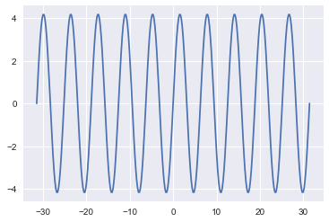

[output not shown]

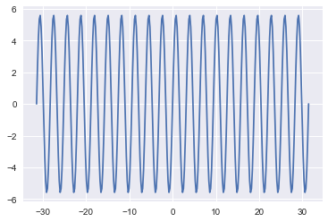

```python
samples_list = []
for i in periods:
    waves = create_wave_sample(150, 301, i, print_stats=True)
    samples_list.append(waves)
```

# TensorFlow Model

## LSTM Cell

```
def lstm_cell(num_units):
    """
    Create LSTM cell

    :param num_units: Number of units in LSTM cell.
    :type num_units: int
    :returns: LSTMCell

    """
    cell = LSTMCell(num_units, state_is_tuple=True)
    return cell
```